# Activity Data Analysis

## Introduction

It is now possible to collect a large amount of data about personal movement using activity monitoring devices such as a Fitbit, Nike Fuelband, or Jawbone Up. These type of devices are part of the “quantified self” movement – a group of enthusiasts who take measurements about themselves regularly to improve their health, to find patterns in their behavior, or because they are tech geeks. But these data remain under-utilized both because the raw data are hard to obtain and there is a lack of statistical methods and software for processing and interpreting the data.

This assignment makes use of data from a personal activity monitoring device. This device collects data at 5 minute intervals through out the day. The data consists of two months of data from an anonymous individual collected during the months of October and November, 2012 and include the number of steps taken in 5 minute intervals each day.

## Loading and Preprocessing

Using **read.csv()** load the activity dataset.

```r
activity <- read.csv("activity.csv", header = T, stringsAsFactors = F)

# View first few rows
head(activity)
```

```
##   steps       date interval
## 1    NA 2012-10-01        0
## 2    NA 2012-10-01        5
## 3    NA 2012-10-01       10
## 4    NA 2012-10-01       15
## 5    NA 2012-10-01       20
## 6    NA 2012-10-01       25
```

```r
# Inspect the columns of data
str(activity)
```

```
## 'data.frame':    17568 obs. of  3 variables:
##  $ steps   : int  NA NA NA NA NA NA NA NA NA NA ...
##  $ date    : chr  "2012-10-01" "2012-10-01" "2012-10-01" "2012-10-01" ...
##  $ interval: int  0 5 10 15 20 25 30 35 40 45 ...
```

```r
# Transform the date attribute to an actual date format
activity$date <- as.POSIXct(activity$date, format="%Y-%m-%d")
```

## What is mean total number of steps taken per day ?

### 1. Calculate the total number of steps taken per day

```r
library(dplyr)
total_num_steps <- activity %>% select("steps", "date") %>% group_by(date) %>% summarise(steps = sum(steps, na.rm = T))
total_num_steps
```

```
## # A tibble: 61 x 2
##          date steps
##        <dttm> <int>
##  1 2012-10-01     0
##  2 2012-10-02   126
##  3 2012-10-03 11352
##  4 2012-10-04 12116
##  5 2012-10-05 13294
##  6 2012-10-06 15420
##  7 2012-10-07 11015
##  8 2012-10-08     0
##  9 2012-10-09 12811
## 10 2012-10-10  9900
## # ... with 51 more rows
```

### 2. If you do not understand the difference between a histogram and a barplot, research the difference between them. Make a histogram of the total number of steps taken each day

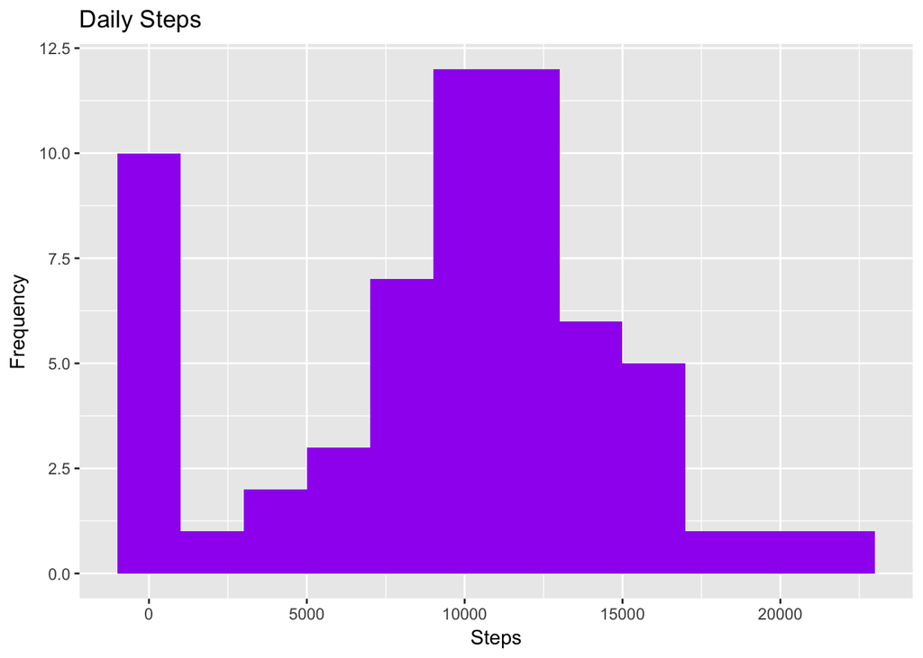

```r
library(ggplot2)

ggplot(total_num_steps, aes(x = steps)) +
    geom_histogram(fill = "Purple", binwidth = 2000) +
    labs(title = "Daily Steps", x = "Steps", y = "Frequency")
```

### 3. Calculate and report the mean and median of the total number of steps taken per day.

```r
paste("Mean of the total number of steps taken per day -", mean(total_num_steps$steps))
```

```
## [1] "Mean of the total number of steps taken per day - 9354.22950819672"
```

```r
paste("Median of the total number of steps taken per day -", median(total_num_steps$steps))
```

```
## [1] "Median of the total number of steps taken per day - 10395"
```

## What is the average daily activity pattern ?

### 1. Make a time series plot (i.e. type=“l”) of the 5-minute interval (x-axis) and the average number of steps taken, averaged across all days (y-axis)

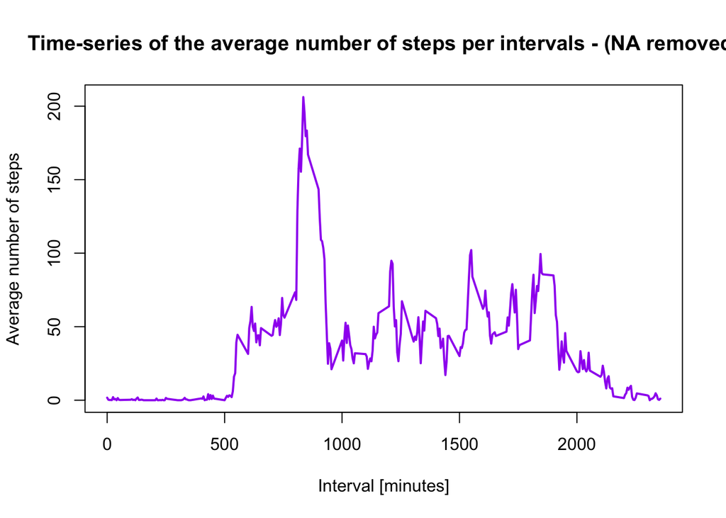

```r
activity_pattern <- activity %>% select("steps", "interval") %>% group_by(interval) %>% summarise(mean_steps = mean(steps, na.rm = T))

# Compute the time series plot
plot(activity_pattern$interval,
     activity_pattern$mean_steps,
     type="l",
     col="Purple",
     lwd=2,
     xlab="Interval [minutes]",
     ylab="Average number of steps",
     main="Time-series of the average number of steps per intervals - (NA removed)")
```

### 2. Which 5-minute interval, on average across all the days in the dataset, contains the maximum number of steps ?

```r
activity_pattern[which.max(activity_pattern$mean_steps), 1]
```

```
## # A tibble: 1 x 1
##   interval
##      <int>
## 1      835
```

The 5-minute interval that contains the maximum of steps, on average across all days, is **835**.

## Imputing missing values

### 1. Calculate and report the total number of missing values in the dataset (i.e. the total number of rows with NAs)

```r
sum(is.na(activity$steps))
```

```
## [1] 2304
```

The number of NA’s is 2304.

### 2. Devise a strategy for filling in all of the missing values in the dataset. The strategy does not need to be sophisticated. For example, you could use the mean/median for that day, or the mean for that 5-minute interval, etc.

```r
for(i in 1:ncol(activity)){
  activity[is.na(activity[,i]), i] <- mean(activity[,i], na.rm = TRUE)
}
```

### 3. Create a new dataset that is equal to the original dataset but with the missing data filled in.

```r
write.csv(x = activity, file = "tidy_data.csv", row.names = F)
```

### 4. Make a histogram of the total number of steps taken each day and Calculate and report the mean and median total number of steps taken per day. Do these values differ from the estimates from the first part of the assignment? What is the impact of imputing missing data on the estimates of the total daily number of steps?

```r
# read tidy data
cleaned_activity <- read.csv("tidy_data.csv", header = T, stringsAsFactors = F)

total_num_steps <- cleaned_activity %>% select("steps", "date") %>% group_by(date) %>% summarise(steps = sum(steps))
total_num_steps
```

```
## # A tibble: 61 x 2
##          date    steps
##         <chr>    <dbl>
##  1 2012-10-01 10766.19
##  2 2012-10-02   126.00
##  3 2012-10-03 11352.00
##  4 2012-10-04 12116.00
##  5 2012-10-05 13294.00
##  6 2012-10-06 15420.00
##  7 2012-10-07 11015.00
##  8 2012-10-08 10766.19
##  9 2012-10-09 12811.00
## 10 2012-10-10  9900.00
## # ... with 51 more rows
```

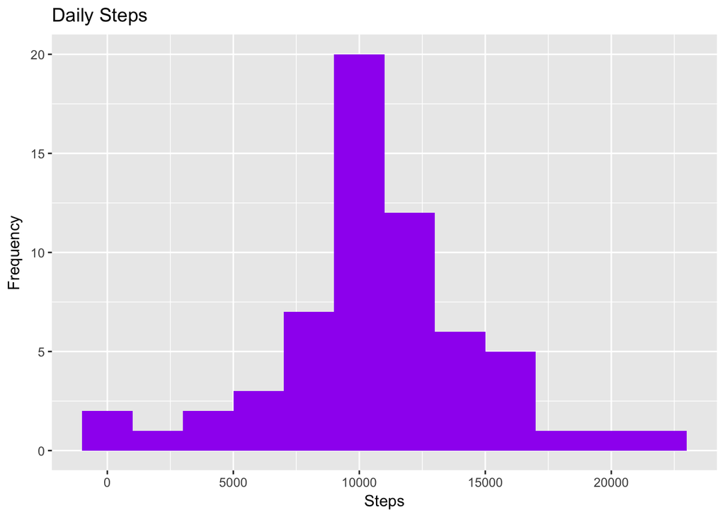

```r
ggplot(total_num_steps, aes(x = steps)) +
    geom_histogram(fill = "Purple", binwidth = 2000) +
    labs(title = "Daily Steps", x = "Steps", y = "Frequency")
```

```r
paste("Mean of the total number of steps taken per day -", mean(total_num_steps$steps))
```

```
## [1] "Mean of the total number of steps taken per day - 10766.1886792453"
```

```r
paste("Median of the total number of steps taken per day -", median(total_num_steps$steps))
```

```
## [1] "Median of the total number of steps taken per day - 10766.1886792453"
```

These formulas gives a mean and median of 10766 and 10766 respectively.

These values differ greatly from the estimates from the first part of the assignment. The impact of imputing the missing values is to have more data, hence to obtain a bigger mean and median value.

## Are there differences in activity patterns between weekdays and weekends ?

### 1. Create a new factor variable in the dataset with two levels – “weekday” and “weekend” indicating whether a given date is a weekday or weekend day.

```r
activity$weekday <- weekdays(activity$date)
activity[grepl(pattern = "Monday|Tuesday|Wednesday|Thursday|Friday", x = activity$weekday), "daytype"] <- "weekday"
activity[grepl(pattern = "Saturday|Sunday", x = activity$weekday), "daytype"] <- "weekend"

activity$daytype <- as.factor(activity$daytype)

str(activity)
```

```
## 'data.frame':    17568 obs. of  5 variables:
##  $ steps   : num  37.4 37.4 37.4 37.4 37.4 ...
##  $ date    : POSIXct, format: "2012-10-01" "2012-10-01" ...
##  $ interval: num  0 5 10 15 20 25 30 35 40 45 ...
##  $ weekday : chr  "Monday" "Monday" "Monday" "Monday" ...
##  $ daytype : Factor w/ 2 levels "weekday","weekend": 1 1 1 1 1 1 1 1 1 1 ...
```

### 2. Make a panel plot containing a time series plot (i.e. type=“l”) of the 5-minute interval (x-axis) and the average number of steps taken, averaged across all weekday days or weekend days (y-axis). See the README file in the GitHub repository to see an example of what this plot should look like using simulated data.

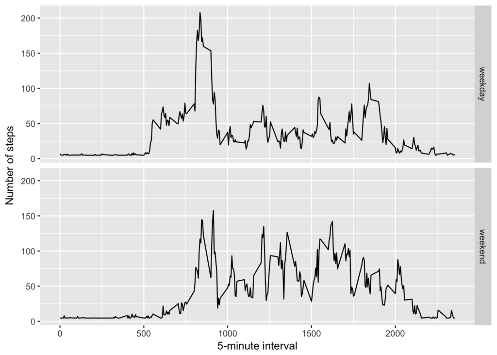

```r
avg <- activity %>% select("steps", "interval", "daytype") %>% group_by(interval, daytype) %>% summarise(steps = mean(steps))

ggplot(avg, aes(interval, steps)) + geom_line() + facet_grid(daytype ~ .) +
    xlab("5-minute interval") + ylab("Number of steps")
```